# Fundamental Techniques in Data Science with `R` - Practical 4

# Introduction

We will use the following packages in this practical:

```r
library(dplyr)
library(magrittr)
library(ggplot2)
library(gridExtra)
```

In this practical, you will learn how to perform regression analyses in `R` using `lm()` and inspect variables by plotting these variables, using `ggplot()`, repeating some topics of the last 3 weeks.

# Loading the dataset

In the this practical, we will use the build-in data set `iris`. This data set contains the measurement of different iris species (flowers), you can find more information [here](https://www.rdocumentation.org/packages/datasets/versions/3.6.2/topics/iris).

1. **Load the dataset and explain what variables are measured in the first three columns of your data set.**

# Inspecting the dataset

A good way of eyeballing on a relation between two continuous variables is by creating a scatterplot.

2. **Plot the sepal length and the petal width variables in a `ggplot` scatter plot (`geom_points`)**

A loess curve can be added to the plot to get a general idea of the relation between the two variables. You can add a loess curve to a ggplot with `stat_smooth(method = "loess")`.

3. **Add a loess curve to the plot under question 2, for further inspection.**

To get a clearer idea of the general trend in the data (or of the relation), a regression line can be added to the plot. A regression line can be added in the same way as a loess curve, the method argument in the function needs to be altered to `lm` to do so.

4. **Change the loess curve of the previous plot to a regression line. Describe the relation that the line indicates.**

# Simple linear regression

With the `lm()` function, you can specify a linear regression model. You can save a model in an object and request summary statistics with the `summary()` command. The model is always specified with the code `outcome_variable ~ predictor`.

When a model is stored in an object, you can ask for the coefficients with `coefficients()`. The next code block shows how you would specify a model where petal width is predicted by sepal width, and how summary statistics for this model would look like

```r
# Specify model: outcome = petal width, predictor = sepal width
iris_model1 <- lm(Petal.Width ~ Sepal.Width,
                  data = iris)

summary(iris_model1)
```

```
##
## Call:
## lm(formula = Petal.Width ~ Sepal.Width, data = iris)
##
## Residuals:
##      Min       1Q   Median       3Q      Max
## -1.38424 -0.60889 -0.03208  0.52691  1.64812
##
## Coefficients:
##             Estimate Std. Error t value Pr(>|t|)
## (Intercept)   3.1569     0.4131   7.642 2.47e-12 ***
## Sepal.Width  -0.6403     0.1338  -4.786 4.07e-06 ***
## ---
## Signif. codes:  0 '***' 0.001 '**' 0.01 '*' 0.05 '.' 0.1 ' ' 1
##
## Residual standard error: 0.7117 on 148 degrees of freedom
## Multiple R-squared:  0.134,  Adjusted R-squared:  0.1282
## F-statistic: 22.91 on 1 and 148 DF,  p-value: 4.073e-06
```

The summary of the model provides:

- The model formula;
- Estimated coefficients (with standard errors and their significance tests);
- Residual information;
- A general test for the significance of the model (F-test);
- (Adjusted) R squared.

Individual elements can be extracted by calling specific model elements (e.g. `iris_model1$coefficients`).

5. **Specify a regression model where Sepal length is predicted by Petal width. Store this model as `model1. Supply summary statistics for this model.**
6. **Based on the summary of the model, give a substantive interpretation of the regression coefficient.**
7. **Relate the summary statistics and coefficients to the plots you made in questions 2 - 4.**

# Multiple linear regression

You can add additional predictors to a model. This can improve the fit and the predictions. When multiple predictors are used in a regression model, it’s called a Multiple linear regression. You specify this model as `outcome_variable ~ predictor_1 + predictor_2 + ... + predictor_n`.

8. **Add Petal length as a second predictor to the model specified as `model1` and store this under the name `model2`, and supply summary statistics. Again, give a substantive interpretation of the coefficients and the model.**

# Categorical predictors

Up to here, we only included continuous predictors in our models. We will now include a categorical predictor in the model as well.

When a categorical predictor is added, this predictor is split in several contrasts (or dummies), where each group is compared to a reference group. In our example Iris data, the variable ‘Species’ is a categorical variable that indicate the species of flower. This variable can be added as example for a categorical predictor. Contrasts, and thus the dummy coding, can be inspected through `contrasts()`.

9. **Add species as a predictor to the model specified as `model2`, store it under the name `model3` and interpret the categorical coefficients of this new model.**

# Model comparison

Now you have created multiple models, you can compare how well these models function (compare the model fit). There are multiple ways of testing the model fit and to compare models, as explained in the lecture and the reading material. In this practical, we use the following:

- AIC (use the function `AIC()` on the model object)
- BIC (use the function `BIC()` on the model object)
- MSE (use `MSE()` of the `MLmetrics` package, or calculate by transforming the `model$residuals`)
- Deviance test (use `anova()` to compare 2 models)
10. **Compare the fit of the model specified under question 5 and the model specified under question 8. Use all four fit comparison methods listed above. Interpret the fit statistics you obtain/tests you use to compare the fit.**

# *OPTIONAL* - Residuals: observed vs. predicted

When fitting a regression line, the predicted values have some error in comparison to the observed values. The sum of the squared values of these errors is the sum of squares. A regression analysis finds the line such that the lowest sum of squares possible is obtained.

The image below shows how the predicted (on the blue regression line) and observed values (black dots) differ and how the predicted values have some error (red vertical lines).

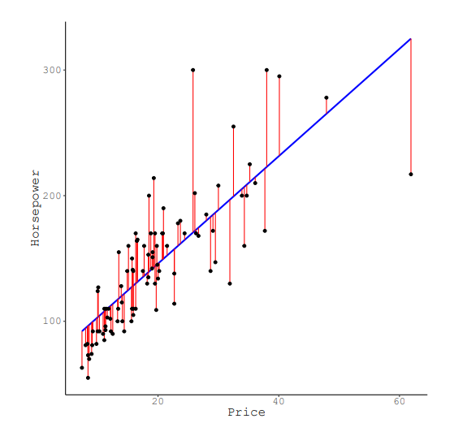

When having multiple predictors, it becomes harder or impossible to make such a plot as above (you need a plot with more dimensions). You can, however, still plot the observed values against the predicted values and infer the error terms from there.

11. **Create a dataset of predicted values for model 1 by taking the outcome variable `Sepal.Length` and the `fitted.values` from the model.**
12. **Create an observed vs. predicted plot for model 1 (the red vertial lines are no must).**
13. **Create a dataset of predicted values and create a plot for model 2.**
14. **Compare the two plots and discuss the fit of the models based on what you see in the plots. You can combine them in one figure using the `grid.arrange()` function.**

# Calculating new predicted values with a regression equation

A regression model can be used to predict values for new cases that were not used to built the model. The regression equation always consists of coefficients ($\beta$s) and observed variables ($X$):

$$\hat{y} = \beta_0 + \beta_1 * X_{a}* +
\beta_2 * X_b + \ldots + \beta_n * X_n$$

All terms can be made specific for the regression equation of the created model. For example, if we have a model where ‘happiness’ is predicted by age and income (scored from 1-50), the equation could look like:

$$\hat{y}_{happiness} = \beta_{intercept}
+ \beta_{age} * X_{age} + \beta_{income} * X_{income}$$

Then, we could impute the coefficients obtained through the model. Given $\beta_{intercept} = 10.2$, $\beta_{age} = 0.7$, and $\beta_{income} = 1.3$, the equation would become:

$$\hat{y}_{happiness} = 10.2 + 0.7 *
X_{age} + 1.3 * X_{income}$$

If we now want to predict the happiness score for someone of age 28 and with an income score of 35, the prediction would become:

$$\hat{y}_{happiness} = 10.2 + 0.7 * 28 +
1.3 * 35 = 75.3$$

15. **Given this regression equation, calculate the predicted value for someone of age 44 and an income score of 27.**

## Prediction with a categorical variable

Adding a categorical predictor to the regression equation gives the number of contrasts as coefficient terms added. The previous regression equation for predicting happiness could be adjusted by adding ‘living density’ as a categorical predictor with levels ‘big city’, ‘smaller city’, ‘rural’, where ‘big city’ would be the reference category. The equation could then be:

$$\hat{y}_{happiness} = 10.2 + 0.7 *
X_{age} + 1.3 * X_{income} + 8.4 * X_{smaller city} + 17.9 *
X_{rural}$$

When predicting a score for an equation with a categorical predictor, you just impute a 1 for the category that the observation belongs to, and 0s for all other categories.

16. **Given this equation, calculate the predicted score for someone of age 29, an income score of 21, and living in a smaller city. And what would this score be if the person would live in a big city instead?**

## Prediction with an interaction

In regression equations with an interaction, an extra coefficient is added to the equation. For example, the happiness equation with age and income as predictors could have an added interaction term. The equation could then look like:

$$\hat{y}_{happiness} = 10.2 + 0.7 *
X_{age} + 1.3 * X_{income} + 0.01 * X_{age} * X_{income}$$

For a person of age 36 and income score 30, the predicted score would be:

$$\hat{y}_{happiness} = 10.2 + 0.7 * 36 +
1.3 * 30 + 0.01 * 36 * 30 = 85.2$$

17. **Given this regression equation with interaction term, what would be the predicted happiness score for someone of age 52 and income score 26?**